# Econometria Aplicada à Finanças Aula 6

Mestrado Profissional em Administração

Prof. Washington Santos da Silva

IFMG - Campus Formiga

23 de setembro de 2025

## Diário de Bordo

**O que vimos até o momento?**

- Aula 1 ✅
  - Apresentação da Disciplina ✅
  - Introdução ao RStudio ✅
  - Configurando o Projeto da Disciplina ✅
  - Conheça e Utilize o Terminal Git Bash ✅
- Aula 2 ✅
  - Git e GitHub: Visão Geral ✅
  - Introdução ao Sistema: Visão Geral ✅
  - Linguagem R: Visão Geral ✅
  - Sessão Prática 1 ✅
- Aula 3 ✅
  - Minicurso Intensivo: Teoria da Probabilidade - Parte 1 ✅
    - Introdução à Teoria da Probabilidade ✅
    - Variáveis Aleatórias e Distribuições de Probabilidade ✅
    - Distribuições Conjunta, Marginal e Condicional ✅
    - Independência de Variáveis Aleatórias ✅
- Aula 4 ✅
  - Minicurso Intensivo: Teoria da Probabilidade - Parte 2 ✅
    - Conceitos Básicos: Revisão
    - Momentos de Distribuições de Probabilidade Univariadas
    - Funções de Variáveis Aleatórias
    - Fundamentos de Distribuições de Probabilidade Multivariadas
    - Cálculo Diferencial e Integral em R
- Aula 5 ✅
  - Minicurso Intensivo: Teoria da Probabilidade - Parte 3 ✅
  - Distribuições de Variáveis Aleatórias Discretas
  - Distribuições de Variáveis Aleatórias Contínuas
  - Distribuições de Vetores Aleatórios
  - A Ponte entre Probabilidade e Estatística/Econometria

## Nesta Aula

**Minicurso Intensivo: Métodos de Inferência Estatística**

- Estimação de Parâmetros: O Básico
- Métodos de Estimação de Parâmetros
- Estimação pode Intervalos de Confiança
- Testes de Hipóteses (**próxima aula**)

**Diretrizes para Aulas Mais Produtivas**

⌨️ **Código com método:**

95% dos erros são evitáveis com:

- Respeitar a sequência lógica de etapas
- Revisão antes de pedir ajuda
- Atenção na digitação

🤝 **Inteligência colaborativa:**

- Compartilhe conhecimento
- Resolva questões técnicas simples com colegas próximos
- Reserve ao professor as dúvidas conceituais complexas

💪 **Capacidade de Resolver Problemas**

Cada problema/erro resolvido é uma evolução da sua habilidade analítica

# Estimação de Parâmetros: O Básico

## Introdução

**Contexto**

- Esta é seção é onde saímos do mundo da “probabilidade” para o mundo da “estatística”.
- Veremos as ideias básicas sobre **estimação** e estabeleceremos a estrutura para pensar sobre estimação e as análises de dados que veremos no restante da disciplina.
- Em termos gerais, estatística é o estudo de métodos de estimação de parâmetros e de inferência sobre esses parâmetros.
- Por enquanto, vamos nos concentrar na **estimação pontual de parâmetros**.
- Na última aula, vimos um importante exemplo de **estimador**, a **média amostral**, mas uma discussão mais geral é importante.
- E, espero, entendemos que um estimador é uma **função das variáveis aleatórias** em uma amostra aleatória.

## Parâmetro

**Conceito**

- Um **parâmetro** é uma quantidade fixa (mas geralmente desconhecida) que especifica um membro de uma **família paramétrica** de distribuições.
- Formalmente, uma família paramétrica de distribuições é um conjunto:
  $$\mathcal{F} = \{ P_\theta : \theta \in \Theta \},$$

  onde:
  - $\theta$ é o **parâmetro** (escalar ou vetor) que identifica uma distribuição específica dentro da família;
  - $\Theta$ é o **espaço paramétrico**, ou seja, o conjunto de todos os valores possíveis de $\theta$.
- Exemplos de parâmetros de famílias de distribuições:
  - Binomial: $n, p$
  - Poisson: $\lambda$
  - Normal: $\mu, \sigma^2$
  - Uniforme: $a, b$
- É comum usar $\theta$ como notação geral para o parâmetro (que pode ser escalar ou vetor).
- Exemplos:
  - Binomial: $\theta = (n, p)$
  - Poisson: $\theta = \lambda$
  - Normal: $\theta = (\mu, \sigma^2)$
  - Uniforme: $\theta = (a, b)$

## Parâmetros

**Estimadores de Parâmetros**

- Normalmente, queremos determinar os valores dos parâmetros que governam um processo ou fenômeno aleatório observado — **estimando parâmetros desconhecidos**.
- Frequentemente, usaremos $\hat{\theta}$ como notação geral para um estimador de um parâmetro.

## Distinção Importante

**Variáveis Aleatórias**

Devemos pensar em variáveis aleatórias de **duas** maneiras:

1. como a construção matemática que apresentei há algumas semanas, ou seja, uma **função** do espaço amostral ($S$) para os números reais ($\mathbb{R}$);
2. e como um objeto estocástico que pode “assumir” diferentes realizações com diferentes probabilidades.

Usamos a notação $X$ para representar a variável aleatória, como sempre, e usamos $x$ para representar a realização (ou possíveis realizações).

Também podemos chamar as realizações dessas variáveis aleatórias de **amostra aleatória**, ou simplesmente **dados**.

#### Amostra aleatória

**Def.** Conjunto de variáveis aleatórias i.i.d (independentes e identicamente distribuídas).

## Estatística, Estimador e Estimativa

**Definições**

- Em outras palavras, presumimos que a amostra aleatória, composta por variáveis aleatórias independentes e identicamente distribuídas (i.i.d.), segue uma distribuição específica, como a normal, a uniforme ou a binomial, entre outras.
- O problema da estimação consiste em determinar os valores dos parâmetros dessa distribuição — por exemplo, $\mu$ e $\sigma^2$ na normal, $a$ e $b$ na uniforme, ou $\lambda$ na Poisson, etc.
- **Def.:** Uma **estatística** é qualquer função de uma amostra $(X_1,\ldots,X_n)$
- **Def.:** Um **estimador** $\hat \theta$ para um parâmetro $\theta$ é uma estatística cujo objetivo é estimar um parâmetro $\theta$.
- Quando inserimos as realizações da amostra aleatória, ou dados, em um estimador para obter um número, temos uma estimativa.
- **Def.:** Uma **estimativa** é um valor específico de um estimador para uma amostra específica.

## Estimação

**Discussão**

- Essa discussão pode parecer excessivamente vaga ou abstrata, mas voltar para tentar entendê-la renderá dividendos no futuro, à medida que nos aprofundarmos sobre estimadores e estimativas.
- Vejamos alguns exemplos de estimadores.
- O primeiro exemplo envolve a distribuição **uniforme** e como podemos **estimar** $\theta$ se temos uma amostra aleatória de uma distribuição $U[0, \theta]$.

## Estimação

**Exemplo 1**

Suponha $X \sim U[0, \theta]$, que implica na seguinte fdp:

$$f_X(x) =
\begin{cases}
\frac{1}{\theta}, & 0 \leq x \leq \theta \\
0, & \text{caso contrário}
\end{cases}$$

Se temos uma amostra aleatória de VAs desta distribuição mas não conhecemos $\theta$, como podemos proceder?

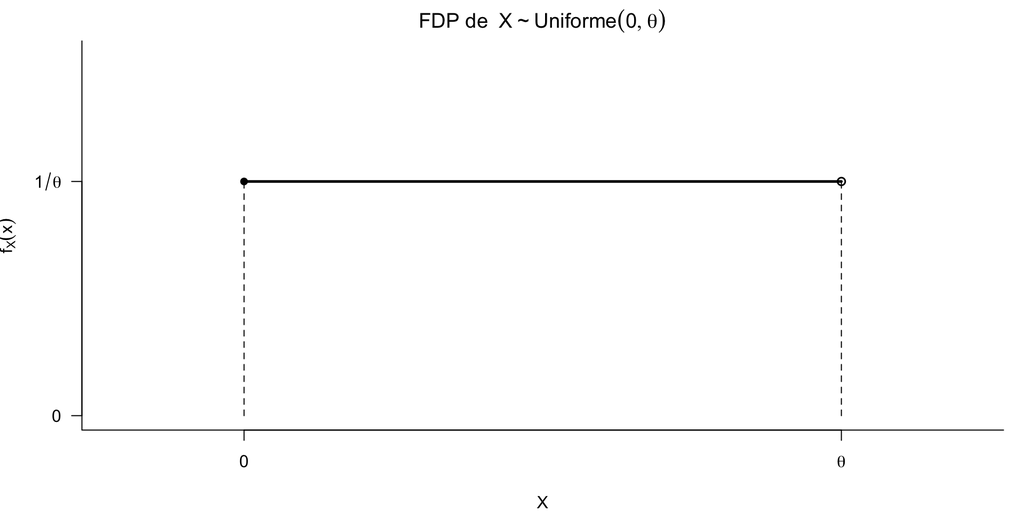

Dois **estimadores** razoáveis vêm à mente:

#### Estimador 1: Máximo Amostral

Obtemos uma amostra aleatória e calculamos a estatística máxima (n-ésima estatística de ordem) da amostra aleatória. Usamos isso como $\hat{\theta_1}$. Ou seja, o estimador é dado por:

$$\hat{\theta_1} = \max \{X_1, X_2, \ldots, X_n\}$$

#### Estimador 2: $2 \cdot \overline{X}$

Reúna uma amostra aleatória, calcule a média amostral e multiplique por 2. Usamos isso como $\hat{\theta_2}$

$$\hat{\theta}_2 = 2 \cdot \frac{1}{n} \sum_{i=1}^n X_i$$

## Comportamento de $\hat{\theta_1}$

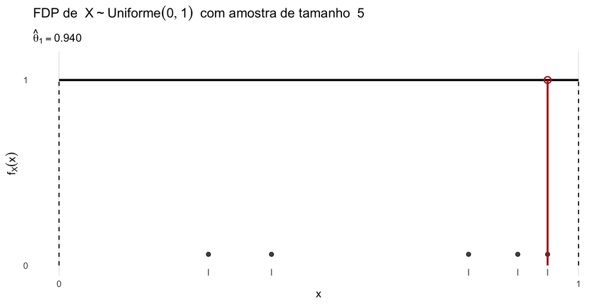

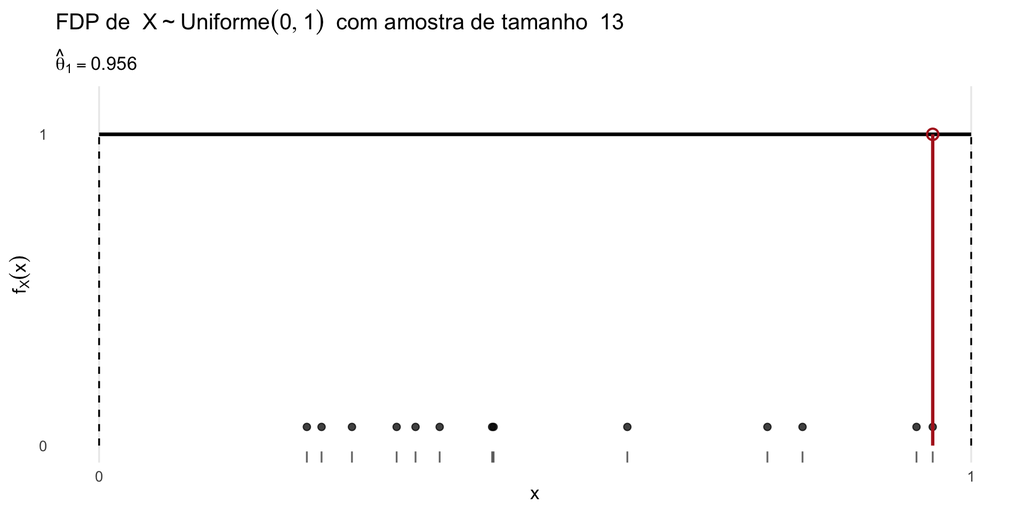

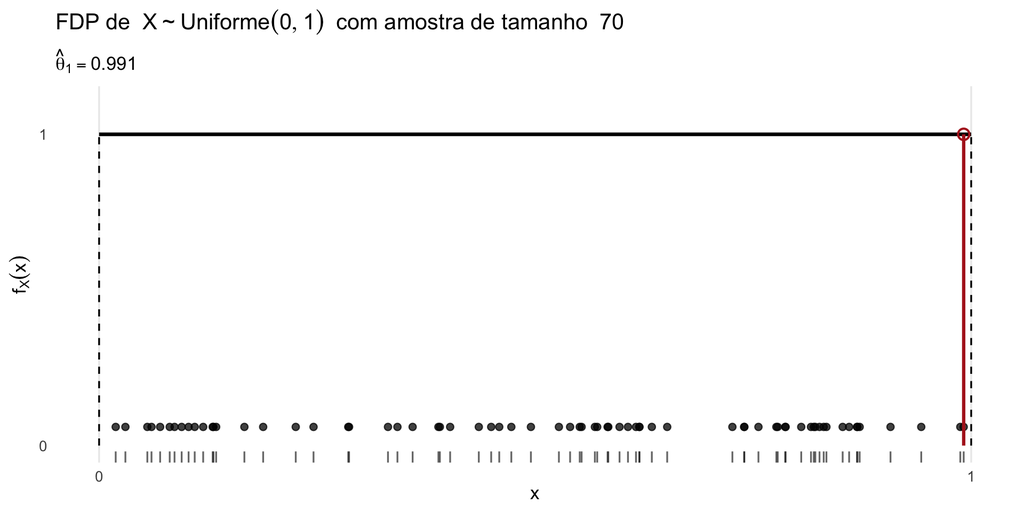

## Comportamento de $\hat{\theta_1}$

**Descrição**

- $\hat{\theta_1}$ se aproxima de $\theta$ à medida que $n$ aumenta.
- $\hat{\theta_1}$ parece ser sempre menor que $\theta$, i.e, parece subestimar $\theta$.
- Para $n$ realmente grande, podemos imaginar que $\hat{\theta_1}$ seria um estimador bastante acurado de $\theta$.

## Comportamento de $\hat{\theta_2}$

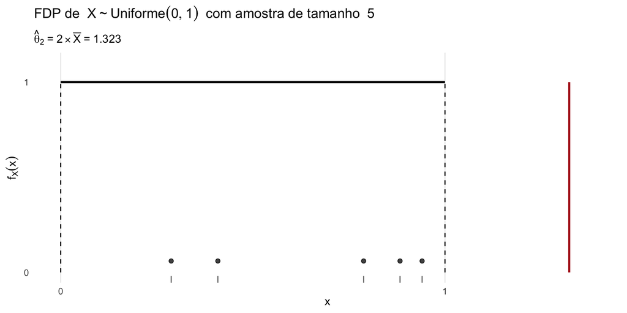

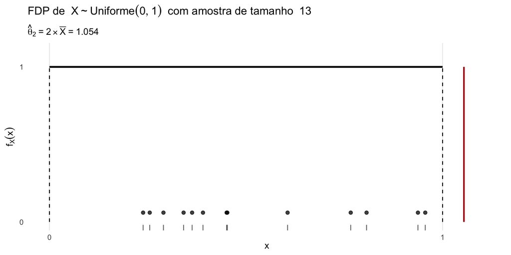

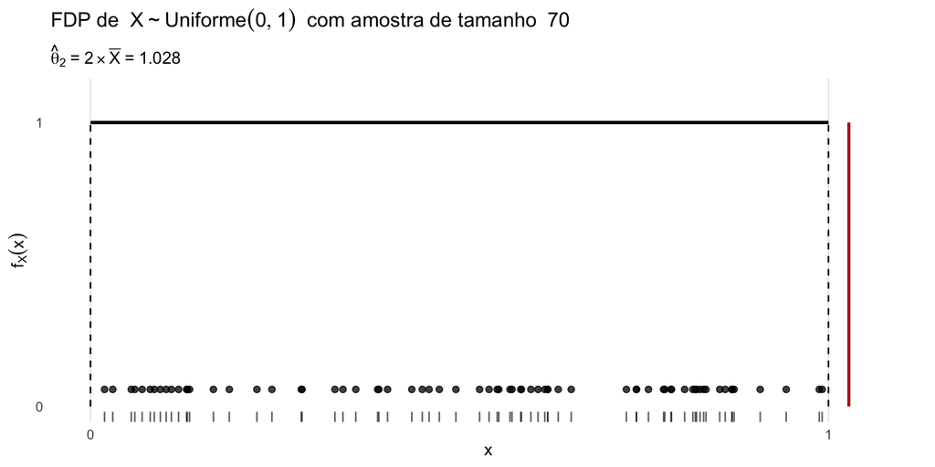

## Comportamento de $\hat{\theta_2}$

**Descrição**

- Você provavelmente pode ver como $\hat{\theta_2}$ também se aproxima de $\theta$ à medida que $n$ aumenta.
- $\hat{\theta_2}$ parece oscilar/**variar** mais que $\hat{\theta_1}$.
- E poderíamos pensar em diversos outros estimadores possíveis.

## Exemplos

**Conclusão**

- Esse exemplo mostrou duas maneiras diferentes de obter informações de uma amostra aleatória de $U[0,1]$ e usá-las para dizer algo sobre o parâmetro desconhecido $\theta$, em outras palavras, para **estimar** $\theta$.
- Mas, provaveilmente, o exemplo levantou mais perguntas do que respostas:
- **Como chegar a essas funções/estimadores?**
- **Como saber que ela(e)s são razoáveis?**
- **Como escolher entre elas/eles?**
- Vamos encontrar maneiras sistemáticas de responder a essas perguntas. Antes disso, porém, tente pensar em um exemplo de um estimador realmente ruim. Existem inúmeros exemplos.
- Você poderia, por exemplo, sempre escolher $\hat{\theta} = 0$, independentemente da sua amostra aleatória,
- Ou escolher $\hat{\theta} = 1/\max\{X_1, X_2,\ldots,X_n\}$, que diminui à medida que a $n$-ésima estatística de ordem aumenta.
- Pode ser útil ter em mente todos esses exemplos, tanto de estimadores razoáveis quanto não razoáveis, à medida que continuamos nossa discussão.

## Critérios para Avaliar Estimadores

**Introdução**

- Agora, voltamos nossa atenção para responder a uma das perguntas anteriores: **Como sabemos que um estimador é razoável?**
- Queremos estabelecer alguns **critérios** para julgar o desempenho de estimadores.
- Lembre-se de que um **estimador é uma função de variáveis aleatórias** e, assim, um **estimador é uma variável aleatória**. Portanto, um estimador tem uma **distribuição de probabilidade** associada.
- Chamamos essa distribuição de **distribuição amostral** do estimador

## Critérios para Avaliar Estimadores

**Distribuição Amostral: Conceito**

- Frequentemente chamamos a distribuição de probabilidade de um estimador de **distribuição amostral**, pois é a distribuição de probabilidade induzida pela amostragem.
- Quando um estimador $\theta = f(X_1,\ldots, X_n)$ é uma função de uma amostra i.i.d. (e nada mais), sua distribuição é determinada pela distribuição $F$ das observações, pelo tamanho da amostra $n$ e pela forma funcional do estimador.
- A distribuição amostral de $\theta$ é tipicamente desconhecida, em parte porque a distribuição $F$ é desconhecida.
- O objetivo de um estimador $\theta$ é aprender sobre um parâmetro $\theta$. Para fazer inferências precisas e medir a precisão de nossas medições, precisamos saber algo sobre sua distribuição amostral.
- Portanto, um esforço considerável na teoria estatística/econométrica é entender a distribuição amostral de estimadores.
- E os critérios para avaliar estimadores serão baseados nas **características de suas distribuições amostrais**.

## Critérios para Avaliar Estimadores

**Veremos os seguintes critérios**

- **Não Tendenciosidade**
- **Eficiência**
- **Erro Quadrático Médio**
- **Consistência**

## Não Tendenciosidade

**Definição: Viés de um Estimador**

O viés de um estimador $\hat \theta$ de um parâmetro $\theta$ é dado por:

$$Viés(\hat \theta) = E(\hat \theta) - \theta$$

**Estimador não-viesado**

Um estimador é **não-viesado** para um parâmetro $\theta$, se $E(\hat \theta) = \theta$ para todo $\theta \in \Theta$.

- Ou seja, um estimador é não-viesado se $Viés(\hat \theta) = 0$.
- Esse critério requer que a distribuição amostral de um estimador seja centrada no parâmetro desconhecido.

## Estimador Não-Viesado: $E(\hat \theta) = \theta$

[figure not shown]

## Estimador Viesado: $E(\hat \theta) = \theta + \text{viés}$

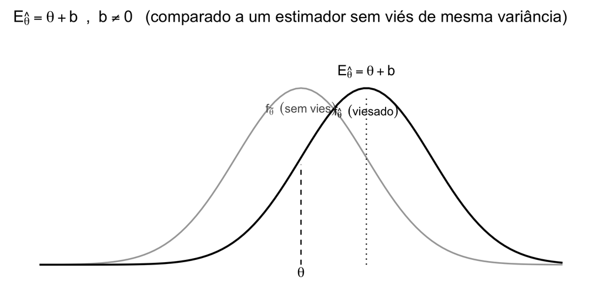

## Retornando ao Exemplo da $U[0,\theta]$

**$\hat{\theta}_2$ é um estimador não-viesado de $\theta$?**

Lembrando que o estimador é definido por:

$$\hat{\theta}_2 = 2 \cdot \bar{X} = 2 \cdot \frac{1}{n} \sum_{i=1}^n X_i$$

Vamos calcular sua expecativa (valor esperado):

$$\begin{align*}
E(\hat{\theta}_2)
&= E\left(2 \cdot \frac{1}{n} \sum_{i=1}^n X_i \right) \\
&= 2 \cdot \frac{1}{n} \sum_{i=1}^n E(X_i)
&& E(c) = c \,e\, \text{(linearidade da esperança)} \\
&= 2 \cdot \frac{1}{n} \sum_{i=1}^n \frac{\theta}{2}
&& \text{(pois $X_i \sim U[0, \theta] \Rightarrow E(X_i) = \frac{\theta}{2}$)} \\
&= 2 \cdot \frac{1}{n} \cdot n \cdot \frac{\theta}{2} \\
E(\hat{\theta}_2) &= \theta
\end{align*}$$

Portanto, $\hat{\theta}_2$ é um estimador **não-viesado** de $\theta$.

## $\hat{\theta_1}$ é um estimador não-viesado de $\theta$?

**Retornando ao Exemplo**

Nesse caso, não podemos usar apenas as propriedades de $E(X)$, precisamos calcular $E(\hat{\theta_1})$ diretamente

$$E(\hat{\theta}_1) = \int_{0}^{\theta} x f_{\theta_1}(x) dx$$

Ou seja, precisamos da fdp de $\hat{\theta}_1$, mas vimos que a fdp de uma estatística de ordem é dada por:

Assim:

$$\begin{align*}
E(\hat{\theta}_1) &= \int_{0}^{\theta} x f_{\theta_1}(x) dx \\
&= \int_{0}^{\theta} xn \frac{x^{n-1}}{\theta^n} dx \\
&= \frac{n}{\theta^n} \int_{0}^{\theta} x^n dx \\
&= \frac{n}{\theta^n} \frac{x^{n + 1}}{n + 1} \bigg\rvert_{0}^{\theta} \\
E(\hat{\theta}_1) &= \frac{n}{n + 1} \theta
\end{align*}$$

Portanto, $\hat{\theta}_1$ é um estimador **viesado** de $\theta$.

Talves esse resultado não seja surpreendente. Notamos anteriormente, que $\hat{\theta}_1$ tende a ser menor que $\theta$.

## Resultados do Exemplo

**Resultados**

- Outra coisa importante surgiu dessa exemplo.
- O cálculo da expectativa de $\hat{\theta}_2$ não envolveu a distribuição específica, sugerindo um resultado mais geral.
- De fato, já provamos o seguinte teorema na última aula:

#### Teorema

A média amostral ($\overline{X}_n$) de uma amostra aleatória é um estimador não-viesado da média populacional ($\mu$) se $E(X) < \infty$.

*prova:*

$$\begin{align*}
E[\overline{X}_n] &= E\left[\frac{\sum_{i=1}^n X_i}{n}\right] \\
&= \frac{1}{n} \sum_{i=1}^n E[X_i] \\
&= \frac{1}{n} \sum_{i=1}^n \mu \\
&= \frac{1}{n} \cdot n\mu \\
E[\overline{X}_n] &= \mu
\end{align*}$$

#### Teorema

A variância amostral ($s^2$) de uma amostra aleatória é um estimador não-viesado da variância populacional: $E(s^2) = \sigma^2$, sendo a variância amostral dada por:

$$s^2 = \frac{1}{n-1} \sum_{i=1}^n (X_i - \overline{X}_n)^2$$

*prova:*

A prova não é difícil mas não é particularmente instrutiva, então a omitiremos.

## Eficiência

**Definição**

Dados dois estimadores não-viesados, $\hat{\theta}_1$ e $\hat{\theta}_2$, $\hat{\theta}_2$ é mais eficiente que $\hat{\theta}_1$ se, para um dado tamanho de amostra: $V(\hat{\theta}_2) < V(\hat{\theta}_1)$

**Observação**

Definimos eficiência aqui apenas estimadores não-viesados, mas, a noção de eficiência pode existir para uma classe mais ampla de estimadores.

## Eficiência: $V(\hat{\theta}_2) < V(\hat{\theta}_1)$

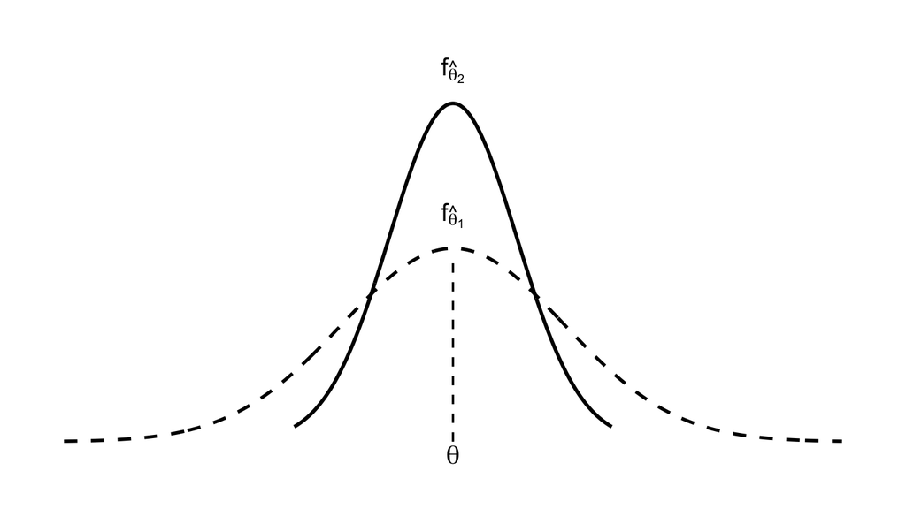

## Erro Quadrático Médio

**Motivação**

- Algumas vezes estamos interessados no trade-off entre viés e variância/eficiência.
- Em outras palavras, podemos estar dispostos a aceitar um pouco de viés em um estimador, se podemos obter um com um pouco menos de variância.
- É nesta situação que entra o erro quadrático médio.

#### Teorema

Para qualquer estimador $\hat \theta$ de um parâmetro $\theta$, com variância finita, seu erro quadrático médio (EQM) é dado por: $V(\hat \theta) + (viés[\hat \theta])^2$.

**prova**:

$$\begin{align*}
EQM(\hat \theta) &= E[(\hat \theta - \theta)^2] \\
&= E[ (\hat \theta - E(\hat \theta) + E(\hat \theta) - \theta)^2] \\
&= E[ (\hat \theta - E(\hat \theta))^2] + (E[\hat \theta] - \theta)^2 +2E[(\hat \theta - E(\hat \theta)(E(\hat \theta) - \theta)]
\\
&= V[\hat \theta] + (E[\hat \theta] - \theta)^2 \\
&= V(\hat \theta) + (Viés[\hat \theta])^2
\end{align*}$$

- Podemos ver que quando um estimador é não-viesado, seu EQM é igual à sua variância.

## Consistência

**Definição**

Seja $\theta$ um parâmetro de interesse e seja $\hat \theta_N$ um estimador de $\theta$. O subscrito $N$ deixa claro que $\theta_N$ é uma variável aleatória que é uma função do tamanho da amostra $N$. O estimador $\hat \theta_N$ é consistente se ele *converge em probabilidade* para $\theta$. Formalmente,

$$\lim_{n \rightarrow \infty} P(|\theta - \hat{\theta}_n| < \epsilon) = 1$$

Podemos pensar essa definição como: escolha qualquer $\epsilon > 0$ muito pequeno, então, podemos encontrar um $N$ tal que $|\theta - \hat{\theta}_n|$ seja menor que $\epsilon$.

Em outras palavras, é uma afirmação sobre como $\hat{\theta}_n$ se comporta quando $N$ aumenta. Em particular, a afirmação é que podemos tornar $\hat{\theta}_n$ arbitrariamente próximo de $\theta$ ao aumentar $n$.

A definição anterior é geralmente simplificada para:

$$\operatorname*{plim} \hat{\theta}_n = \theta$$

Em termos visuais, um estimador é consistente se sua distribuição colapsa para um único ponto no parâmetro verdadeiro à medida que $n \rightarrow \infty$.

## Consistência

[figure not shown]

{T1, T2, T3, …} é uma sequência de estimadores para o parâmetro $\theta$, cujo valor verdadeiro é 4. Essa sequência é consistente: os estimadores estão se concentrando cada vez mais perto do valor verdadeiro $\theta = 4$ à medida que $n$ aumenta.; ao mesmo tempo, repare que esses estimadores são viesados. A distribuição limitante da sequência é uma variável aleatória degenerada que é igual a $\theta$ com probabilidade 1.

## Estimadores Viesados e Inconsistentes

**Nota**

Em econometria, o pior tipo de estimador que podemos ter é aquele que é **viesado** e **inconsistente**.

Um estimador **viesado** não converge, em média, para o verdadeiro valor do parâmetro, ou seja:

$$E(\hat{\theta}) \neq \theta$$

Um estimador **inconsistente** não converge para o verdadeiro valor do parâmetro nem mesmo com amostras grandes:

$$\hat{\theta}_n \not\overset{p}{\longrightarrow} \theta$$

Quando um estimador possui **ambas** essas propriedades — viés e inconsistência — ele falha tanto em amostras pequenas quanto grandes, o que compromete qualquer inferência econométrica confiável.

Este é precisamente o problema central da **endogeneidade**: ela gera estimadores que são **viesados e inconsistentes**.

A endogeneidade ocorre quando uma variável explicativa está correlacionada com o termo de erro do modelo, violando a suposição fundamental de exogeneidade:

$$\operatorname{Cov}(X, \varepsilon) \neq 0$$

Essa violação leva a inferências incorretas, pois os estimadores obtidos por Mínimos Quadrados Ordinários (MQO) não refletem o verdadeiro efeito causal da variável explicativa sobre a variável dependente.

## Endogeneidade

**Nota**

- O problema da **endogeneidade** foi tão central para o desenvolvimento da econometria moderna que levou, nas últimas décadas, a uma verdadeira transformação na forma de conduzir inferência causal em economia e nas demais ciências sociais.
- A busca por estratégias que produzam estimadores válidos (não-viesados e/ou consistentes)  
  mesmo na presença de endogeneidade impulsionou o surgimento de métodos quasi-experimentais e fortaleceu o papel da **identificação** causal na econometria aplicada.

## Critérios para Avaliar Estimadores

**Considerações Finais**

- Esses critérios são provavelmente os mais conhecidos para escolher um estimador. Mas há outros, por exemplo:
- Podemos considerar o **quão simples** é o cálculo de um estimador;
- Ou, o quão **robusto** um estimador é em relação às hipóteses utilizadas para sua derivação (i.e, se um estimador ainda possuirá boas propriedades se assumimos a distribuição errada?).

# Métodos de Estimação de Parâmetros

## Introdução

**Visão Geral**

- Agora sabemos como descobrir se um estimador é bom quando temos um.
- Mas **como podemos obter um estimador?**
- Na escola frequentista da estatística, existem dois métodos principais para derivar estimadores:
- **Método dos Momentos**, e;
- **Método da Máxima Verossimilhança**.

## Método dos Momentos

**História**

- O Método dos Momentos foi desenvolvido em 1894 por Karl Pearson, o pai da estatística matemática.
- A ideia é simples e intuitiva, embora um pouco difícil de descrever.
- Em primeiro lugar precisamos relembrar o conceito de momento não central, agora chamado de **momento populacional**.
- E definir o conceito de **momento amostral**.

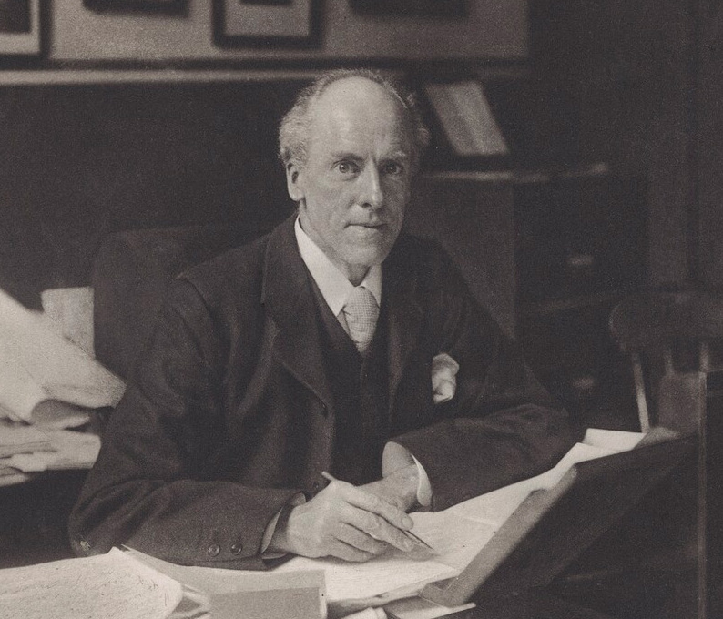

## Método dos Momentos

**Conceitos**

#### Momentos Populacionais (não centrados)

São expectativas de potências de uma variável aleatória, eles serão funções dos parâmetros (desconhecidos) da distribuição de $X$:

$E(X)$, $E(X^2)$, $E(X^3)$, e assim por diante.

#### Momentos Amostrais

São as médias amostrais de potências das variáveis aleatórias em uma amostra aleatória:

$\dfrac{1}{n} \sum_{i=1}^n X_i$, $\dfrac{1}{n} \sum_{i=1}^n X_i^2$, $\dfrac{1}{n} \sum_{i=1}^n X_i^3$, e assim por diante.

## Método dos Momentos

**Procedimento**

Para estimar um parâmetro, iguale o primeiro momento populacional (uma função do parâmetro) ao primeiro momento amostral e resolva para o parâmetro.

#### Exemplo

No exemplo envolvendo a distribuição uniforme, $\hat \theta_2$ é um estimador construído pelo método dos momentos.

Lembre-se que o primeiro momento populacional (valor esperado, média) de uma VA com distribuição uniforme contínua é dado por $E(X) = \dfrac{a + b}{2}$

#### Primeiro Momento Populacional

No exemplo, $X \sim U[0,\theta]$, ou seja $a = 0$ e $b = \theta$, portanto: o primeiro momento populacional de $X$ é

$$E(X) = \frac{0 + \theta}{2} = \frac{\theta}{2}$$

#### Primeiro Momento Amostral

O primeiro momento amostral é:

$$\frac{1}{n} \sum_{i=1}^n X_i$$

#### Igualando os Momentos

Então, igualamos os primeiros momentos populacional e amostral, colocamos um chapéu em $\theta$ e resolvemos para $\hat \theta$:

$$\begin{align*}
\frac{\hat \theta}{2} &= \frac{1}{n} \sum_{i=1}^n X_i \\
\hat \theta &= 2\frac{1}{n} \sum_{i=1}^n X_i \\
\hat \theta &= 2\overline{X}_n
\end{align*}$$

## Método dos Momentos

**E se tivermos mais parâmetros para estimar?**

- E se tivermos mais de um parâmetro para estimar?
- Sem problema — basta usar quantos momentos amostrais e populacionais forem necessários.
- Cada um é chamado de “**condição de momento**”.
- Se tivermos $k$ parâmetros para estimar, teremos $k$ condições de momento.
- Em outras palavras, teremos que resolver um sistema de $k$ equações com $k$ incógnitas.

## Método Generalizado dos Momentos

**Resumo e Papel em Econometria**

- O **Método Generalizado dos Momentos (GMM)** é uma extensão do método dos momentos, formalizado por Lars Peter Hansen em 1982 (Hansen, 1982), que foi prêmio Nobel de Economia em 2013 por esse trabalho.
- Ele permite estimar modelos econométricos baseando-se em **condições de momento** derivadas de suposições teóricas sobre a relação entre variáveis e seus resíduos.
- Diferente do método clássico dos momentos, o GMM **permite lidar com modelos com mais condições de momento do que parâmetros a serem estimados** (sistema sobre-identificado).
- Em sua formulação geral, o GMM escolhe os estimadores dos parâmetros $\hat{\theta}$ que minimizam uma **função objetivo quadrática**, que mede a distância entre os momentos amostrais e os momentos teóricos implicados pelo modelo:

$$\hat{\theta}_{GMM} = \arg\min_{\theta} \; g_n(\theta)' W_n g_n(\theta)$$

onde:

- $g_n(\theta) = \frac{1}{n} \sum_{i=1}^n g(Z_i, \theta)$ é o vetor de momentos amostrais,
- $W_n$ é uma matriz de ponderação simétrica e definida positiva,
- E $g(Z_i, \theta)$ representa as condições de momento: $E[g(Z_i, \theta)] = 0$

Se o modelo está **sobre-identificado** (mais momentos do que parâmetros), o GMM escolhe os valores de $\theta$ que mais se aproximam de satisfazer todas as condições simultaneamente.

- O GMM é amplamente utilizado em **econometria aplicada**, especialmente quando há problemas de **endogeneidade**, **variáveis instrumentais**, **dados em painel** e **modelos dinâmicos**.

## Método da Máxima Verossimilhança

**História**

- Estimação por Máxima Verossimilhança (de origem obscura que remonta a séculos, mas a ideia é geralmente atribuída a Lagrange, por volta de 1770, e sua formalização à Ronald A. Fisher, por volta de 1930);
- O estimador de máxima verossimilhança de um parâmetro $\theta$ é o valor $\hat \theta$ que mais provavelmente teria gerado a amostra observada.

[figure not shown]

J-L Lagrange e Ronald Fisher

## Método da Máxima Verossimilhança

**Visão Intuitiva**

- Suponha que você coletou uma amostra aleatória de um fenômeno aleatório modelado como uma variável aleatória de interesse e fez um histograma dos dados, lembre-se que um histograma (ou uma estimativa do kernel da densidade) é uma estimativa empírica da fdp de uma variável aleatória.

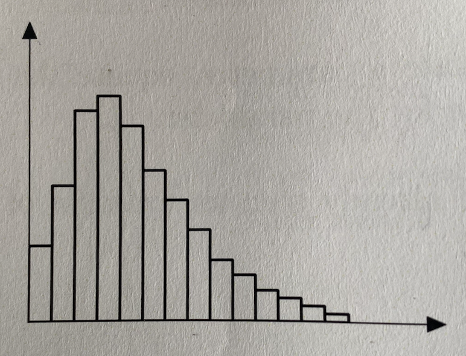

Histograma dos dados observados

- A imagem abaixo apresenta algumas FDPs que poderiam ter gerado os dados observados. De onde tiramos essas FDPs? Bem, assumimos uma “família” específica de distribuições e variamos o(s) parâmetro(s).

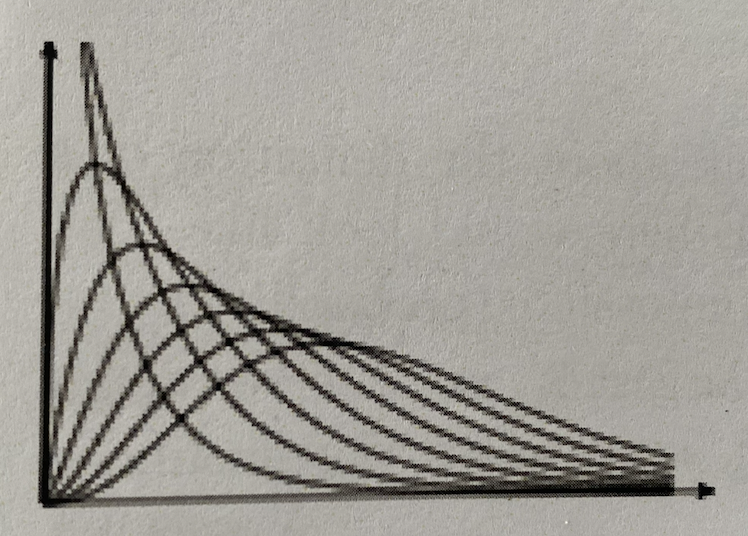

Possíveis FDPs que podem ter gerado os dados

- Qual dessas possíveis FDPSs é mais provável de ter produzido os dados observados?
- O(s) parâmetro(s) que determinam essa FDP são os estimadores/estimativas de máxima verossimilhança.

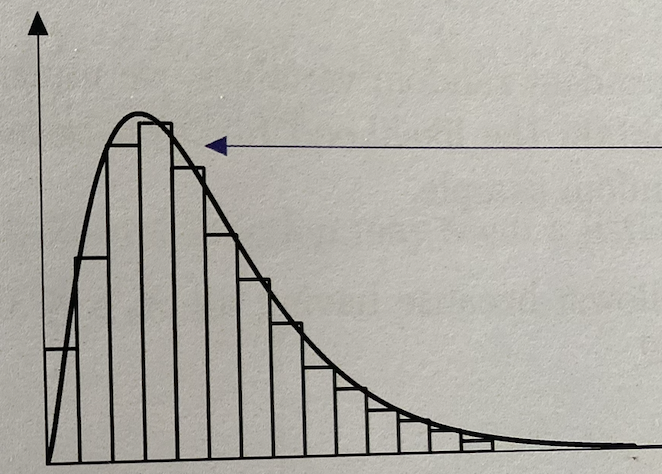

Qual dessas possíveis FDPSs é mais provável de ter produzido os dados observados?

- Conceitualmente, faz sentido. Do ponto de vista operacional, como identificamos, dentre um conjunto FDPs, qual delas é a mais provável de ter gerado os dados observados?

## Método da Máxima Verossimilhança

**EMV - Operacionalização**

- O Método da Máxima Verossimilhança (EMV) consiste em reinterpretar a função densidade de probabilidade (FDP) conjunta de uma amostra aleatória como uma função dos parâmetros desconhecidos $\theta$, mantendo os dados fixos.
- Essa nova função é chamada de **função de verossimilhança**, denotada por $L(\theta | x)$, e é definida por:

$$L(\theta | x) = \prod_{i=1}^n f(x_i | \theta)$$

onde:

- $x = (x_1, \dots, x_n)$ são os dados observados;
- $f(x_i | \theta)$ a FDP dos dados, assumindo uma família paramétrica;
- $\theta \in \Theta$ o espaço paramétrico admissível.
- O objetivo é encontrar o valor de $\theta$ que **maximiza** $L(\theta | x)$, ou, de forma equivalente, maximiza o logaritmo da verossimilhança:

$$\log L(\theta | x) = \sum_{i=1}^n \log f(x_i | \theta)$$

Isso é feito porque o logaritmo é uma função crescente e transforma produtos em somas, facilitando a diferenciação e a análise.

#### Resumo do Procedimento

1. Especificar uma família de distribuições que pode ter gerado os dados observados.
2. Escrever a função de verossimilhança $L(\theta | x)$ como a FDP conjunta da amostra.
3. Tomar o logaritmo da função de verossimilhança para obter $\log L(\theta | x)$.
4. Derivar a função de log-verossimilhança e **igualar a primeira derivada a zero** (condição de primeira ordem para um máximo).
5. Calcular a **segunda derivada** e verificar seu sinal (condição de segunda ordem para um máximo).
6. Se a derivada segunda for negativa, o ponto encontrado é um **máximo local** para $\theta$, e $\hat \theta$ é o estimador de máxima verossimilhança de $\theta$.

## Por que o termo “verossimilhança”?

**Função de verossimilhança ≠ Probabilidade**

A função de verossimilhança mede o **grau de compatibilidade** entre os dados observados e diferentes valores possíveis do parâmetro $\theta$.

A função de verossimilhança **não é uma probabilidade**, pois não integra nem soma para 1 em relação ao parâmetro.

#### Diferença fundamental

| Conceito | Dados fixos ou variáveis? | Parâmetros fixos ou variáveis? | Objetivo |
| --- | --- | --- | --- |
| **Probabilidade** | Dados variáveis | Parâmetros fixos | Calcular $P(x \mid \theta)$ |
| **Verossimilhança** | Dados fixos | Parâmetros variáveis | Avaliar $L(\theta \mid x)$ |

$$L(\theta \mid x) = p^x (1 - p)^{1 - x}$$

Para o dado observado $x = 1$, temos:

$$L(\theta \mid x = 1) = p^1 (1 - p)^0 = p = \theta$$

$$\hat{\theta} = \arg\max_{p \in [0,1]} L(p \mid x=1) = 1$$

Esse é o estimador de máxima verossimilhança (EMV) para $\theta$, dado que observamos $x = 1$.

#### Terminologia

O termo **verossimilhança**, traduzido do inglês *likelihood*, foi introduzido por Ronald Fisher para destacar uma mudança fundamental de perspectiva: os **dados observados são tratados como fixos**, enquanto o parâmetro $\theta$ passa a ser considerado **variável**, no sentido de que queremos estimá-lo.

A função de verossimilhança, portanto, mede quão **verossímil*** (**compatível**) é cada valor possível de $\theta$ com os dados observados.

## Método da Máxima Verossimilhança

**Derivação do Estimador de Máxima Verossimilhança de de $p$**

Suponha $k$ amostras independentes $x_1,\ldots,x_k$ de uma VA $X$ que segue uma distribuição $\operatorname{Binomial}(n,p)$. Sabemos que a função de probabilidade de $Y$ é dada por:

$$P(X=x) = f_X(x) = \binom{n}{y}p^{y}(1-p)^{\,n-y}$$

#### Função de verossimilhança

$$\begin{aligned}
L(p|x) &= \prod_{i=1}^{k} f_X(x_i) \\
L(p|x) &= \prod_{i=1}^{k}\binom{n}{x_i}p^{x_i}(1-p)^{n-x_i}, \\
L(p|x) &\propto \prod_{i=1}^{k} p^{x_i} (1 - p)^{n - x_i} \, \text{(ignorando a constante)} \, \binom{n}{x_i}
\end{aligned}$$

#### Função de log-verossimilhança

Portanto, a função de log‑verossimilhança é:

$$\log L(p) = \sum_{i=1}^k\bigl[x_i\,\log p+(n-x_i)\,\log(1-p)\bigr]$$

#### Condição de 1ª ordem

$$\frac{\partial \log L(p)}{\partial p}=\frac{\sum x_i}{p}-\frac{kn-\sum x_i}{1-p} = 0$$

Multiplicando por $p(1-p)$ e isolando $p$:

$$\hat p = \frac{\sum x_i}{kn}=\bar x$$

#### Condição de 2ª ordem

$$\frac{\partial^{2} \log L(p)}{\partial p^{2}}=-\frac{\sum x_i}{p^{2}}-\frac{kn-\sum x_i}{(1-p)^{2}}<0$$

Logo $\hat p$ maximiza $L(p)$ e, portanto, é o estimador de máxima verossimilhança de $p$.

# Estimação por Intervalo de Confiança

## Estatística

**Quantificando a Confiabilidade**

- Vimos alguns **estimadores**, fizemos observações sobre suas **distribuições amostrais**, discutimos como podemos derivá-los e também discutimos **critérios** que podemos usar para escolher entre eles.
- Tudo isso é muito bom, mas quando realmente precisamos reportar estimativas de parâmetros, as pessoas vão querer ter alguma medida objetiva de quão boas, confiáveis ou precisas são n ossas estimativas.
- Uma maneira de quantificar isso é reportando a variância (ou variância estimada) do estimador junto com a estimativa.

## Revisão: Distribuição Amostral da Média

**Retomando a média amostral**

Lembre-se da definição:

$$\overline{X}_n = \frac{1}{n}\sum_{i=1}^n X_i$$

- Se $X_i$ são i.i.d. com média $\mu$ e variância $\sigma^2$:

$$E[\overline{X}_n] = \mu,
\quad
V[\overline{X}_n] = \frac{\sigma^2}{n}$$

- Ou seja, a média amostral é **não viesada** e sua variância diminui com $n$.

## Distribuição da Média Amostral

**Casos Importantes**

- **Caso Normal**: Se $X_i \sim N(\mu, \sigma^2)$, então:

$$\overline{X}_n \sim N\!\left(\mu, \tfrac{\sigma^2}{n}\right)$$

- **Caso Geral**: Se $X_i$ não são normais, mas têm média $\mu$ e variância $\sigma^2$:

$$\sqrt{n}\, \frac{\overline{X}_n - \mu}{\sigma}
\;\;\overset{d}{\longrightarrow}\;\; N(0,1)
\quad \text{(Teorema Central do Limite)}$$

- Assim, $\overline{X}_n$ é **aproximadamente normal** em amostras grandes.

## Erro-Padrão de um Estimador

**Definição**

O erro-padrão de um estimador é definido como a raíz quadrada da variância da distribuição amostral do estimador:

$$ep(\hat{\theta}) = \sqrt{V(\hat{\theta})}$$

## Erro-Padrão da Média

**Definição**

O erro-padrão da média amostral é:

$$ep(\overline{X}_n) = \sqrt{V(\overline{X}_n)}
= \frac{\sigma}{\sqrt{n}}
\quad \text{(quando $\sigma^2$ é conhecida).}$$

Se $\sigma^2$ é desconhecida, usamos o estimador $s^2$:

$$ep(\overline{X}_n) \approx \frac{s}{\sqrt{n}}$$

Isso conecta a **distribuição da média amostral** ao **erro-padrão**, base para construir intervalos de confiança.

## Erro-Padrão de um Estimador

**Erros-padrão devem ser reportados!**

- Uma vez que precisamos de uma medida objetiva de quão boas, confiáveis ou precisas são nossas estimativas.
- Assim, frequentemente relatamos uma estimativa pontual de um parâmetro junto com seu erro padrão.
- É comum colocarmos o erro padrão entre parênteses logo após a estimativa pontual.

## Estatística

**Quantificando a Confiabilidade**

- O erro padrão certamente nos dá uma ideia de quão fortemente concentrada em torno do parâmetro desconhecido está a distribuição amostral do estimador.
- Isso é útil, mas às vezes pode ser útil relatar informações essencialmente equivalentes em um formato diferente, um intervalo.
- Em outras palavras, podemos construir um intervalo usando informações sobre a distribuição amostral do estimador.
- Esse intervalo será estreito quando o estimador tiver uma distribuição estreita e amplo quando tiver uma distribuição dispersa.
- Esse intervalo é denominado **intervalo de confiança**.

## Intervalos de Confiança

**Definição**

Queremos encontrar funções de uma amostra aleatória: $I(X_1, X_2,\ldots, X_n)$ e $S(X_1, X_2,\ldots, X_n)$ tal que:

$$P[I(X_1, X_2,\ldots, X_n) < \theta < S(X_1, X_2,\ldots, X_n)] = 1 - \alpha$$

Para entender a definição, devemos nos lembrar que:

$$P[\underbrace{I(X_1, X_2,\ldots, X_n)}_{\text{variável aleatória}} <
\underbrace{\theta}_{\text{verdadeiro parâmetro} \\ \text{fixo, mais desconhecido}} <
\underbrace{S(X_1, X_2,\ldots, X_n)}_{\text{variável aleatória}}] = 1 - \alpha$$

Se pudermos encontrar as funções $I$ e $S$, então:

$$[I(X_1, X_2,\ldots, X_n), S(X_1, X_2,\ldots, X_n)]$$

é denominado intervalo de confiança de nível $1 - \alpha$ para $\theta$.

$(1 - \alpha)$ é também denominado **probabilidade de cobertura** do intervalo, ou seja, a probabilidade do intervalo aletatório conter o verdadeira parâmetro de $\theta$.

## Intervalos de Confiança

**Interpretação Formal**

- Um intervalo com 95% de confiança, por exemplo, implica que, se fossem retiradas 100 amostras e fossem obtidas 100 estimativas por IC, espera-se que 95% dos intervalos calculados contenham o valor verdadeiro do parâmetro.
- A Fig. 1 ilustra 100 estimativas de IC $[I(x_1,\ldots,x_n), S(x_1,\ldots,x_n)]$ para um parâmetro $\theta$, com base em 100 amostras extraídas de alguma população. Os 5 intervalos em vermelho não incluem $\theta$.

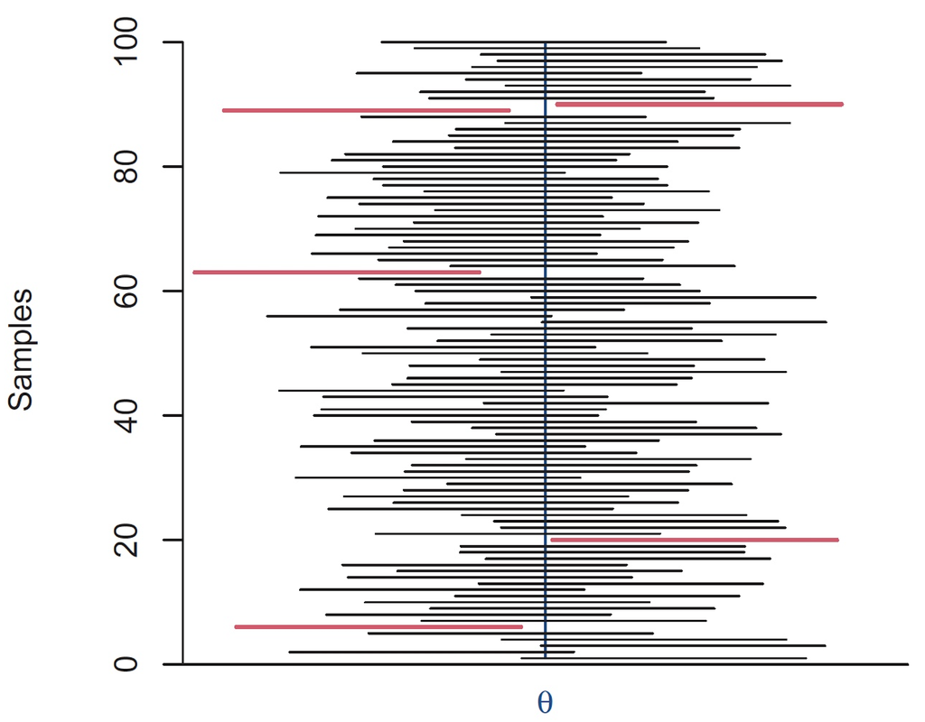

Figura 1: Intervalos de confiança de 95% para um parâmetro $\theta$ com base em 100 amostras separadas de uma população. Os intervalos de confiança em vermelho são aqueles que não incluem $\theta$.

## Intervalos de Confiança

**Como encontrar as funções $I$ e $S$?**

- Onde encontramos essas funções? Bem, você pode derivá-las “do zero”.
- Na maioria dos casos que você encontrará na análise de dados cotidiana, porém, outros encontraram essas funções e uma fórmula resultante.
- Importante observar que para encontrar essas funções e derivar a fórmula, é preciso saber como um estimador do parâmetro desconhecido é distribuído (normalmente não apenas a média e a variância), ou seja, é preciso saber a distribuição amostral do parâmetro.
- Nesses casos, basta usar a fórmula já padrão. De fato, um pequeno ramo da estatística matemática surgiu há várias décadas para derivar a distribuição dos estimadores em algumas situações padrão, apenas para que pudéssemos construir intervalos de confiança (e realizar outros tipos de inferências) com esses estimadores padrão.
- Se você já se deparou com alguma estatística ou análise de dados na vida, quase certamente já ouviu falar delas.

## Distribuições $\chi^2$, $t$ e $F$

**$\chi^2$, $t$ e $F$ são Distribuições Amostrais**

- É precisamente aqui que entram as famosas distribuições $\chi^2$, $t$ e $F$.
- Todas elas são distribuições que, ao contrário de outras distribuições que encontramos, não aparecem de fato na natureza, não descrevem fenômenos aleatórios que observamos.
- Em vez disso, foram “inventadas” porque estimadores ou funções de estimadores tinham distribuições que precisavam ser descritas e tabuladas.

## A Variância Amostral

**Definição**

A variância amostral ($s^3$) é dada por:

$$s^2 = \frac{1}{n-1}\sum_{i=1}^n (X_i - \overline{X}_n)^2$$

Mas por que $s^2$ tem essa forma?

## Estimador da Variância

**Estimador de $\sigma^2$ pelo Método dos Momentos**

O segundo momento populacional central é:

$$\mu_2 = E[(X-\mu)^2] = \sigma^2.$$

O segundo momento amostral central é:
$$m_2 = \frac{1}{n}\sum_{i=1}^n (X_i-\overline{X})^2.$$

Agora, igualamos $\mu_2$ a $m_2$ e obtemos o estimador MOM:

$$\hat{\sigma}^2 \;\;=\;\; m_2
\;=\; \frac{1}{n}\sum_{i=1}^n (X_i-\overline{X})^2.$$

Mas esse estimador **é viesado**. Vamos demonstrar o viés.

#### Demonstração do Viés

Usamos a identidade algébrica:

$$\sum_{i=1}^n (X_i-\overline{X})^2
=
\sum_{i=1}^n (X_i-\mu)^2 \;-\; n(\overline{X}-\mu)^2.$$

Tomando esperança (com $X_i$ i.i.d., $E[X_i]=\mu$, $V(X_i)=\sigma^2$):

$$E\!\left[\sum_{i=1}^n (X_i-\overline{X})^2\right]
=
n\,\sigma^2 \;-\; n\,\operatorname{Var}(\overline{X})
=
n\,\sigma^2 \;-\; n\left(\frac{\sigma^2}{n}\right)
=
(n-1)\sigma^2.$$

Logo:

$$E\!\left[\hat{\sigma}^2\right]
=
E\!\left[\frac{1}{n}\sum_{i=1}^n (X_i-\overline{X})^2\right]
=
\frac{n-1}{n}\,\sigma^2.$$

Portanto, $\hat{\sigma^2}$ é um estimador **viesado**.

#### Correção de viés

Para eliminar o viés do estimador dado por:

$$\hat{\sigma}^2 = \frac{1}{n}\sum_{i=1}^n (X_i-\overline{X})^2,$$

multiplicamos por $\dfrac{n}{n-1}$ e obtemos

$$s^2 \;\equiv\; \hat{\sigma}^2_{\text{corr}}
= \frac{n}{n-1}\,\tilde{\sigma}^2_{\text{MOM}}
= \frac{1}{n-1}\sum_{i=1}^n (X_i-\overline{X})^2.$$

#### Demonstração de que $E[s^2]=\sigma^2$

**Hipóteses.** $X_1,\ldots,X_n$ i.i.d., $E[X_i]=\mu$, $\operatorname{Var}(X_i)=\sigma^2<\infty$.

Denote $\overline{X}=\frac{1}{n}\sum_{i=1}^n X_i$.

1. Identidade chave (dispersão em torno da média amostral)

$$\sum_{i=1}^n (X_i-\overline{X})^2
= \sum_{i=1}^n (X_i-\mu)^2 \;-\; n(\overline{X}-\mu)^2.$$

Derivação:

$$\begin{align*}
X_i-\overline{X} &= (X_i-\mu)-(\overline{X}-\mu) \Rightarrow \\
\sum (X_i-\overline{X})^2 &= \sum (X_i-\mu)^2 - 2(\overline{X}-\mu)\sum (X_i-\mu) + n(\overline{X}-\mu)^2.
\end{align*}$$

Como $\sum (X_i-\mu)=n(\overline{X}-\mu)$, o termo cruzado é $2n(\overline{X}-\mu)^2$, e portanto:

$$\begin{align*}
\sum (X_i-\overline{X})^2 & =\sum (X_i-\mu)^2 - 2n(\overline{X}-\mu)^2 + n(\overline{X}-\mu)^2 \\
&=\sum (X_i-\mu)^2 - n(\overline{X}-\mu)^2.
\end{align*}$$

2. Tomando esperança termo a termo:

$$E\!\left[\sum_{i=1}^n (X_i-\overline{X})^2\right]
= E\!\left[\sum_{i=1}^n (X_i-\mu)^2\right] - n\,E\!\left[(\overline{X}-\mu)^2\right].$$

3. Cálculos das expectativas:

$$E\!\left[\sum_{i=1}^n (X_i-\mu)^2\right] = \sum_{i=1}^n \operatorname{Var}(X_i) = n\sigma^2$$

$$E\!\left[(\overline{X}-\mu)^2\right] = \operatorname{Var}(\overline{X}) = \dfrac{\sigma^2}{n}$$

pela independência.

4. Conclusão intermediária:

$$E\!\left[\sum_{i=1}^n (X_i-\overline{X})^2\right]
= n\sigma^2 - n\left(\frac{\sigma^2}{n}\right)
= (n-1)\sigma^2.$$

5. Espectativa de $s^2$

$$E[s^2]
= E\!\left[\frac{1}{n-1}\sum_{i=1}^n (X_i-\overline{X})^2\right]
= \frac{1}{n-1}\,(n-1)\sigma^2
= \sigma^2.$$

**Conclusão.**

$$s^2 = \frac{1}{n-1}\sum_{i=1}^n (X_i-\overline{X})^2$$

é um estimador **não viesado** de $\sigma^2$

## Distribuição $\chi^2$ (qui-quadrado)

**Origem**

Acabamos de verficar que:

$$s^2 = \frac{1}{n - 1} \sum_{i = 1}^n (X_i - \overline{X}_n)^2$$

é um estimador não viesado da variância populacional.

Karl Pearson demonstrou que uma função deste estimador tem a distribuição $\chi^2$ como distribuição amostral:

$$(n-1)\frac{s^2}{\sigma^2} \sim \chi^2(n-1)$$

Sendo $(n - 1)$ o parâmetro da distribuição $\chi^2$, o qual é denominado *graus de liberdade*.

A distribuição qui-quadrado surge **naturalmente** em inferência estatística sempre que:

- Calculamos somas de desvios quadráticos
- Estimamos ou testamos variâncias
- Utilizamos razões de verossimilhança

## Distribuição Qui-Quadrado

**Distribuição $\chi^2$**

VA’s qui-quadrado surgem quando soma-se o quadrado de VA’s independentes com distribuição normal padronizada:

$$V = Z_1^2 + Z_2^2 + \ldots + Z_k^2 \sim \chi^2(k)$$

- A notação $V \sim \chi^2(k)$ é lida como: A VA $V$ tem distribuição $\chi^2$ com $k$ graus de liberdade.
- O número de graus de liberdade $k$ é o número de variáveis independentes que contribuíram para a geração de $V$.
- O valor de $k$ determina a forma da distribuição $\chi^2$, incluindo sua média e variância.

#### Função de Probabilidade

A função de probabilidade da distribuição $\chi^2$ é dada por:

$$\chi^2(k) = \frac{1}{2^{\frac{k}{2}} \Gamma\left(\frac{k}{2}\right)} \cdot x^{\frac{k}{2} - 1} e^{-\frac{x}{2}}$$

#### Momentos

- **Valor Esperado (Média)**: $E[X] = k$
- **Variância**: $V[X] = 2k$

## Distribuição Qui-Quadrado

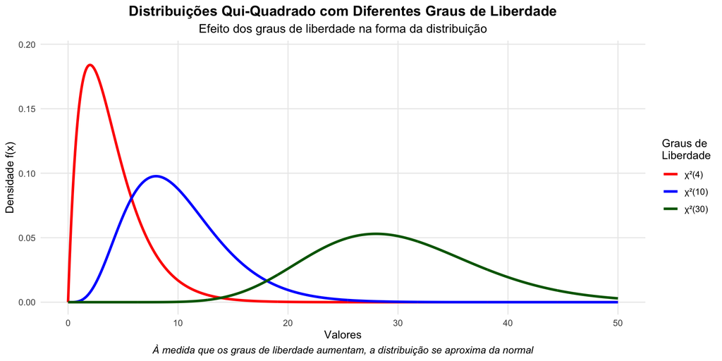

## Funções R para Distribuição Qui-Quadrado

**Funções para a Distribuição Qui-Quadrado**

| Função | Resultado |
| --- | --- |
| `rchisq(n, df, ncp = 0)` | Simula `n` valores |
| `dchisq(x, df, ncp = 0, log = FALSE)` | Densidade $f(x)$ |
| `pchisq(q, df, ncp = 0, lower.tail = TRUE)` | $P(X \le q)$ (FDA) |
| `qchisq(p, df, ncp = 0, lower.tail = TRUE)` | Quantil: $F^{-1}(p)$ |

**Argumentos:**

- `df` = graus de liberdade $(\nu)$;
- `ncp` = parâmetro de não centralidade (0 para qui-quadrado central).

## Distribuição $t$ ❤️

**Origem**

- A distribuição t foi formulada por William Sealy Gosset em seu trabalho como **Cervejeiro-Chefe** na Cervejaria **Guinness** em Dublin.
- Ele derivou e tabulou essa distribuição para auxiliar em sua análise de dados para o **controle de qualidade de** **lotes de cerveja**.
- Ele a publicou sob o pseudônimo de “Student” em 1908.

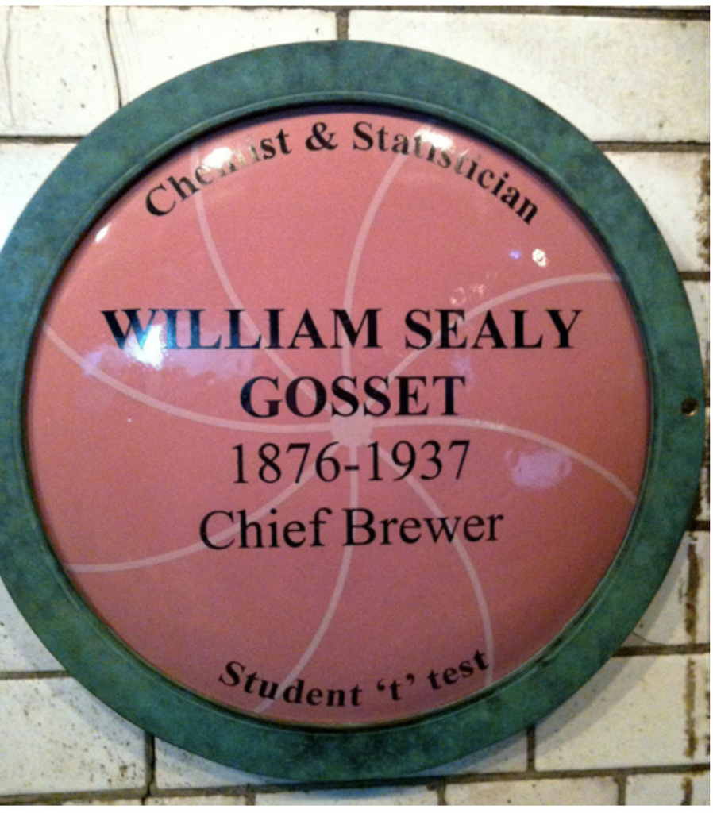

## Distribuição $t$

**Origem**

Queremos inferir a média $\mu$ de uma população normal com variância **desconhecida**.

#### Quando $\sigma^2$ é conhecida

$$Z = \frac{\bar{X} - \mu}{\sigma / \sqrt{n}} \sim \mathcal{N}(0,1)$$

#### Quando $\sigma^2$ é desconhecida

Substituímos $\sigma$ pela variância amostral $s^2$:

$$T = \frac{\bar{X} - \mu}{s / \sqrt{n}}$$

- O numerador continua normal.
- O denominador agora **varia com o tamanho da amostra** ⇒ incerteza extra.

#### Distribuição do denominador

Sabemos que:

$$(n-1)\frac{s^2}{\sigma^2} \sim \chi^2(n-1)$$

#### Fato importante

Quando os $X_i$ são normais, $\bar{X}$ e $S^2$ são **independentes**, isso nos permite formar a razão:

$$T = \frac{Z}{\sqrt{V/k}}
= \frac{\frac{(\bar{X} - \mu)}{\sigma/\sqrt{n}}}{\sqrt{\frac{\sum ((X_i - \bar{X})/ \sigma)^2}{n -1}}}$$

E cancelando alguns termos, obtemos $\dfrac{\bar{X} - \mu}{s/\sqrt{n}} = \dfrac{\sqrt{n}(\bar{X} - \mu)}{s}$

Então, temos que:

$$\dfrac{\sqrt{n}(\bar{X} - \mu)}{s} \sim t_{(n - 1)}, \, \text{para} \, X_i \, i.i.d \, N(\mu, \sigma^2)$$

#### Conclusão

A distribuição t emerge naturalmente ao estimarmos a média com variância **desconhecida** e **amostras pequenas**.

Ela é uma correção da normal padrão para lidar com **incerteza adicional**.

## Distribuição $t$

**Distribuição $t$**

VA’s t surgem quando dividimos uma VA normal padronizada pela raíz quadrada de uma VA com distribuição qui-quadrado dividida pelos seus graus de liberdade:

$$t = \frac{Z}{\sqrt{V/k}} \sim t(k)$$

- A notação $X \sim t(k)$ é lida como: A VA $X$ tem distribuição $t$ de Student com $k$ graus de liberdade.

#### Função de Probabilidade

A função de probabilidade da distribuição $t2$ é dada por:

$$f(t) = \frac{\Gamma\left(\frac{k+1}{2}\right)}{\sqrt{k\pi}\Gamma\left(\frac{k}{2}\right)} \left(1 + \frac{t^2}{k}\right)^{-\frac{k+1}{2}}$$

#### Momentos

- **Valor Esperado (Média)**: $E[X] = 0$ para $k > 1$
- **Variância**: $V[X] = \frac{k}{k-2}$ para $k > 2

## Distribuição $t$

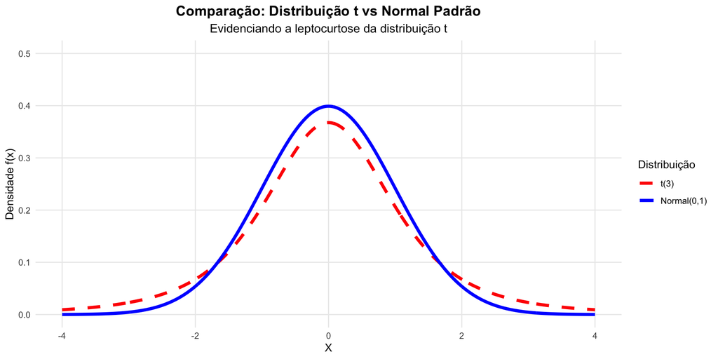

## Funções R para Distribuição t de Student

**Funções para a Distribuição t**

| Função | Resultado |
| --- | --- |
| `rt(n, df, ncp = 0)` | Simula `n` valores |
| `dt(x, df, ncp = 0, log = FALSE)` | Densidade $f(x)$ |
| `pt(q, df, ncp = 0, lower.tail = TRUE)` | $P(T \le q)$ (FDA) |
| `qt(p, df, ncp = 0, lower.tail = TRUE)` | Quantil: $F^{-1}(p)$ |

**Argumentos:**

- `df` = graus de liberdade;
- `ncp` = parâmetro de não centralidade (0 para t central).

## Distribuição $F$

**Origem**

A distribuição $F$ surge naturalmente ao comparar duas variâncias amostrais, e foi derivada por Ronald Fisher em 1922, no contexto da criação da Análise da Variância (ANAVA), que viria a se tornar a principal técnica de inferência na análise de experimentos.

#### Contexto

Se: $X \sim N(\mu_X, \sigma_X^2)$, $Y \sim N(\mu_Y, \sigma_Y^2)$ - e $X$ e $Y$ são independentes, então:

sabemos que:

$$\frac{(n - 1) s_X^2}{\sigma_X^2} \sim \chi^2(n - 1)
\quad\text{e}\quad
\frac{(M - 1) s_Y^2}{\sigma_Y^2} \sim \chi^2(m - 1)$$

Considerando $\sigma_{X}^2 = \sigma_{Y}^2 = \sigma^2$, temos:

$$F = \frac{s_X^2}{s_Y^2}
= \frac{(s_X^2 / \sigma^2)}{(s_Y^2 / \sigma^2)}
= \frac{\chi^2(n - 1)/(n - 1)}{\chi^2(m - 1)/(m - 1)}$$

$$\Rightarrow F \sim F(n - 1, m - 1)$$

#### Aplicações da distribuição F

- Análise da Variância: comparar variabilidade entre grupos
- Teste de igualdade de variâncias
- Regressão linear

#### Conclusão

A distribuição $F$ permite **comparar variâncias**, especialmente sob a suposição de **normalidade**.

## Distribuição $F$

**Distribuição $F$**

#### Origem

VA’s F surgem quando formamos a razão de duas VA’s com distribuição qui-quadrado, divididas pelos seus graus de liberdade:

$$F = \frac{V_1/k_1}{V_2/k_2}$$

- A notação $X \sim F(k_1, k_2)$ é lida como: A VA $X$ tem distribuição $F$ com $k_1$ graus de liberdade no numerador e $k_2$ graus de liberdade no denominador.

#### Função de Probabilidade

$$f(x) = \frac{\sqrt{\frac{(k_1 x)^{k_1} k_2^{k_2}}{(k_1 x + k_2)^{k_1+k_2}}}}{x \cdot B\left(\frac{k_1}{2}, \frac{k_2}{2}\right)}$$

#### Momentos

- **Valor Esperado (Média)**: $E[X] = \frac{k_2}{k_2 - 2}$ para $k_2 > 2$
- **Variância**: $V[X] = \frac{2k_2^2(k_1 + k_2 - 2)}{k_1(k_2 - 2)^2(k_2 - 4)}$ para $k_2 > 4$

## Distribuição $F$

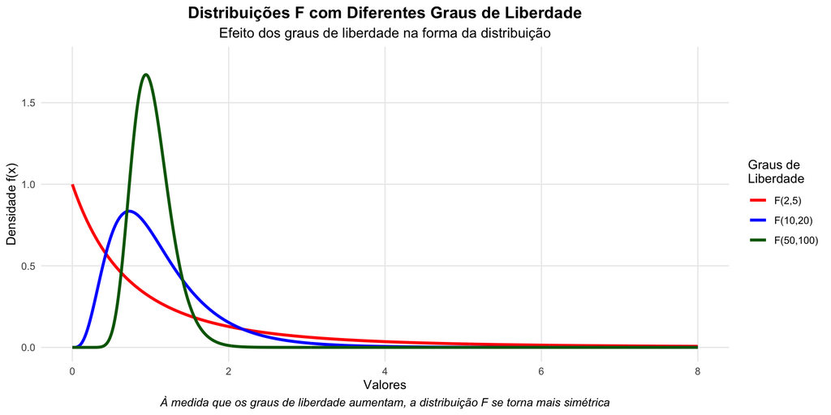

## Funções R para Distribuição F

**Funções para a Distribuição F**

| Função | Resultado |
| --- | --- |
| `rf(n, df1, df2, ncp = 0)` | Simula `n` valores |
| `df(x, df1, df2, ncp = 0, log = FALSE)` | Densidade $f(x)$ |
| `pf(q, df1, df2, ncp = 0, lower.tail = TRUE)` | $P(F \le q)$ (FDA) |
| `qf(p, df1, df2, ncp = 0, lower.tail = TRUE)` | Quantil: $F^{-1}(p)$ |

**Argumentos:**

- `df1` = graus de liberdade do numerador
- `df2` = graus de liberdade do denominador
- `ncp` = parâmetro de não centralidade (0 para F central)

## Intervalos de Confiança

**Casos Importantes**

- Agora que temos as distribuições amostrais, podemos começar a fazer inferências em muitas circunstâncias.
- Então, vamos construir alguns IC. Vamos nos concentrar inicialmente em dois casos. Esses não são os únicos casos que você encontrará, mas são, de longe, os mais importantes.
- **Caso 1:** Estamos amostrando a partir de uma distribuição normal com uma **variância conhecida** e queremos um intervalo de confiança para a média populacional ($\mu$).
- **Caso 2:** Estamos amostrando a partir de uma distribuição normal com uma **variância desconhecida** e queremos um intervalo de confiança para a média populacional ($\mu$).

## Intervalos de Confiança

**Caso 1 ($\sigma^2$ conhecida)**

Temos um estimador para a média, $\overline{X}$, com $E(\overline{X})=\mu$ e $V(\overline{X})=\sigma^{2}/n$.

Logo, o pivô

$$Z=\frac{\overline{X}-\mu}{\sigma/\sqrt{n}}
\sim \mathcal{N}(0,1).$$

Então:

$$P\!\left(
-\,z_{1-\alpha/2}
\;<\;
\frac{\overline{X}-\mu}{\sigma/\sqrt{n}}
\;<\;
z_{1-\alpha/2}
\right)=1-\alpha,
\quad
z_{1-\alpha/2}=\Phi^{-1}(1-\alpha/2).$$

Então, rearranjando, obtemos:

$$P\!\left(
\overline{X} - z_{1-\alpha/2} \frac{\sigma}{\sqrt{n}}
\;<\;
\mu
\;<\;
\overline{X} + z_{1-\alpha/2}\,\frac{\sigma}{\sqrt{n}}
\right)=1-\alpha.$$

**Obs.** Usando a simetria da Normal, podemos escrever $\Phi^{-1}(\alpha/2) = -z_{\alpha/2}$

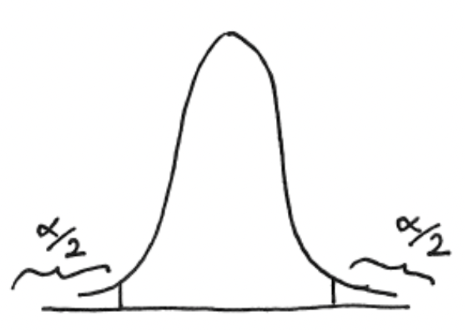

$$P\!\left(
\overline{X} - z_{\alpha/2} \frac{\sigma}{\sqrt{n}}
\;<\;
\mu
\;<\;
\overline{X} + z_{\alpha/2}\,\frac{\sigma}{\sqrt{n}}
\right) = 1-\alpha.$$

Quando inserimos os dados ($\overline{X}$, $\sigma$ e $n$), nosso IC $(1 - \alpha)$ é apenas dois números:

$$\Bigl[ \overline{X} - z_{\alpha/2} \frac{\sigma}{\sqrt{n}},
\overline{X} + z_{\alpha/2}\,\frac{\sigma}{\sqrt{n}} \Bigr]$$

## Intervalos de Confiança

**Caso 2 ($\sigma^2$ desconhecida)**

Temos um estimador para a média, $\overline{X}$, com $E(\overline{X})=\mu$ e $V(\overline{X})=\sigma^{2}/n$, mas não conhecemos $\sigma^2$. Mas, sabemos que:

$$\frac{\sqrt{n}(\overline{X} - \mu)}{s} \sim t_{(n-1)}$$

Portanto, usando um raciocínio similar ao utilizado no caso 1, e a simetria da distribuição $t$, temos:

$$P \Bigl[- t_{(n - 1)}^{-1}(\alpha/2) < \frac{\sqrt{n}(\overline{X} - \mu)}{s} <
t_{(n - 1)}^{-1}(\alpha/2) \Bigr] = 1 - \alpha$$

Então, rearranjando, obtemos:

$$P[\overline{X} - t_{(n - 1)}^{-1}(\alpha/2) \frac{s}{\sqrt{n}} < \mu <
\overline{X} + t_{(n - 1)}^{-1}(\alpha/2) \frac{s}{\sqrt{n}}] = 1 - \alpha$$

Quando inserimos os dados ($\overline{X}$, $s$ e $n$), nosso IC $(1 - \alpha)$ é apenas dois números:

$$\Bigl[ \overline{X} - t_{\alpha/2} \frac{s}{\sqrt{n}},
\overline{X} + t_{\alpha/2}\,\frac{s}{\sqrt{n}} \Bigr]$$

Vamos analisar a imagem que ilustra a diferença entre os casos 1 e 2:

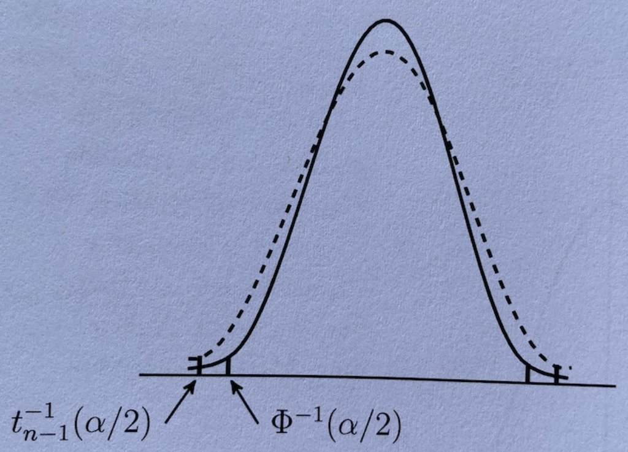

A distribuição t é semelhante à normal, mas tem “caudas mais pesadas” (leptocúrtose) do que a normal.

A distribuição $t$ converge para a distribuição normal à medida que $n \rightarrow \infty$, em particular:

$$t_{(n - 1)}^{-1}(\alpha/2) \rightarrow z_{\alpha/2} \, \text{à medida que} \, n \rightarrow \infty$$

A distribuição $t$ fornece um intervalo mais amplo do que a normal para $n$ finito.

A distribuição $t$ “penaliza” o intervalo de confiança, tornando-o mais amplo, refletindo a maior incerteza.

À medida que n tende ao infinito, a incerteza se torna relativamente menos importante.

## Intervalos de Confiança

**Outros casos**

- Nem sempre nos enquadramos no caso 1 ou no caso 2. O que fazemos então?
- Usando fatos que conhecemps sobre como funções de variáveis aleatórias são distribuídas, podemos construir um intervalo de confiança do zero por conta própria.
- Na prática, geralmente recorremos a resultados semelhantes aos do Teorema Central do Limite para argumentar que o estimador tem uma distribuição normal aproximada, e então usamos a fórmula do intervalo de confiança $t$ com uma variância estimada.
- Para $n$ grande, os intervalos de confiança $t$ e normal são os mesmos.

## Referências

HANSEN, L. P. [Large sample properties of generalized method of moments estimators](https://doi.org/10.2307/1912775). **Econometrica**, v. 50, n. 4, p. 1029–1054, 1982.